# Análisis de expresión diferencial ELI vs NIT

# librerias usadas

```r
library(tidyverse); library(DESeq2); library(apeglm); library(Cairo); library(pheatmap); library(EnhancedVolcano); library(clusterProfiler); library(enrichplot); library(pathview)
library(AnnotationDbi); library(org.Hs.eg.db); library(pheatmap) # el paquete de anotaciones de humanos usando Entrez
```

# Preparación del análisis de expresión de ELI vs NIT

A partir de los datos normalizados con DESeq2 se extraen los resultados de las comparaciones dos a dos, para hacer las comparaciones se pone en el numerador el mayor grado de infiltración (ELI>SFI>NIT), de forma que cuando los genes sobreexpresados serán aquellos que se expresen mas en la muestra con mayor infiltración, en este comparación, los genes sobreexpresados serán los más transcritos en las muestras ELI.

## Filtrado

Se filtran los genes por el fold change (parámetro lfcThreshold) y por el valor de significación (el parámentro alpha). El filtrado por defecto acepta como genes diferencialmente expresados cualquiera que tenga un p-valor menor de 0.1:

```r
load("materiales intermedios/dds_raw.Rda")

eli_nit <- results(dds, contrast=c("Group", "ELI", "NIT"))

summary(eli_nit)
```

```
out of 43224 with nonzero total read count
adjusted p-value < 0.1
LFC > 0 (up)       : 5750, 13%
LFC < 0 (down)     : 4003, 9.3%
outliers [1]       : 0, 0%
low counts [2]     : 11735, 27%
(mean count < 1)
[1] see 'cooksCutoff' argument of ?results
[2] see 'independentFiltering' argument of ?results
```

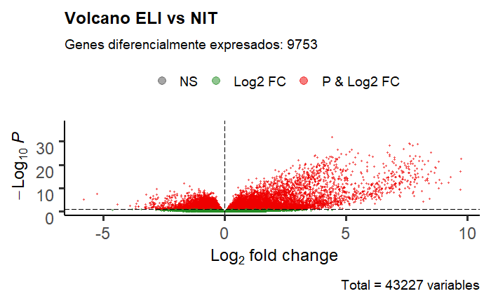

```r
EnhancedVolcano(eli_nit, lab = "", x = 'log2FoldChange', FCcutoff = 0,
                pCutoff = 0.1, y = 'pvalue', title = "Volcano ELI vs NIT",
                subtitle = paste0("Genes diferencialmente expresados: ", sum(eli_nit$padj < 0.1, na.rm=TRUE)),
                gridlines.major = F, gridlines.minor = F)
```

```r
FC <- 1.5; alpha <- 0.05
eli_nit <- results(dds, contrast=c("Group", "ELI", "NIT"), alpha = alpha)

summary(eli_nit)
```

```
out of 43224 with nonzero total read count
adjusted p-value < 0.05
LFC > 0 (up)       : 4785, 11%
LFC < 0 (down)     : 3128, 7.2%
outliers [1]       : 0, 0%
low counts [2]     : 12573, 29%
(mean count < 1)
[1] see 'cooksCutoff' argument of ?results
[2] see 'independentFiltering' argument of ?results
```

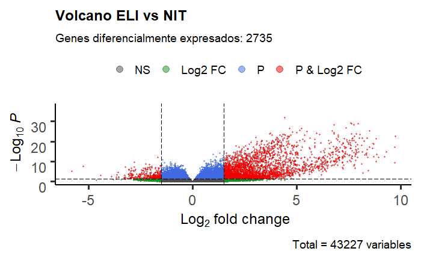

```r
EnhancedVolcano(eli_nit, FCcutoff = FC, lab = "", x = 'log2FoldChange',
                pCutoff = alpha, y = 'pvalue', title = "Volcano ELI vs NIT",
                subtitle = paste0("Genes diferencialmente expresados: ",
                                  sum((eli_nit$padj < alpha)& abs(eli_nit$log2FoldChange)>FC, na.rm=T)),
                gridlines.major = F, gridlines.minor = F, )
```

## Shrink

Encoger (Shrink) el fold change de los genes con pocas cuentas reduce el ruido, es util en rankings y visualización, se puede ver bien en el MA - plot. La forma correcta de encoger los resultados teniendo en cuenta el fold change y alpha según Michael Love (el autor principal de DESEq2) (https://support.bioconductor.org/p/110307/). es la siguiente.

```
res <- results(dds, lfcThreshold=1, ...)
res <- lfcShrink(dds, coef="response_PD_vs_CR+PR", type="apeglm", res=res) # estableciendo el valor de resultado
```

### Tipos de Shrink

Encoger (Shrink) el fold change de los genes con pocas cuentas reduce el ruido, es util en rankings y visualizacion, para evitar filtros extra, que son arbitrarios. En el paquete DESEq hay tres tipos de Shrink, paso a compararlos para elegir el mejor.

```r
eli_nit_shr <- lfcShrink(dds, coef="Group_ELI_vs_NIT", type= "apeglm", res=eli_nit)
eli_nit_ashr <- lfcShrink(dds, contrast=c("Group", "ELI", "NIT"), type = "ashr", res=eli_nit) # Con ashr shrink

par(mfrow=c(1,3))
  plotMA(eli_nit, ylim = c(-5,10), main = "no shrink")
  plotMA(eli_nit_shr, ylim = c(-5,10), main = "apeglm")
```

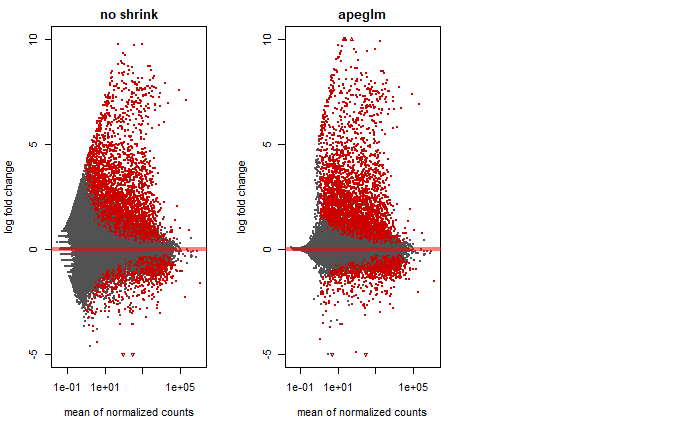

```r
  plotMA(eli_nit_ashr, ylim = c(-5,10), main = "ashr")
```

[output not shown]

```r
summary(eli_nit_ashr)
```

```
out of 43224 with nonzero total read count
adjusted p-value < 0.05
LFC > 0 (up)       : 4785, 11%
LFC < 0 (down)     : 3128, 7.2%
outliers [1]       : 0, 0%
low counts [2]     : 12573, 29%
(mean count < 1)
[1] see 'cooksCutoff' argument of ?results
[2] see 'independentFiltering' argument of ?results
```

```r
(p <- EnhancedVolcano(eli_nit_ashr, FCcutoff = FC, lab = "", x = 'log2FoldChange',
                pCutoff = alpha, y = 'pvalue', title = "Volcano ELI vs NIT",
                subtitle = paste0("Genes diferencialmente expresados: ",
                                  sum((eli_nit_ashr$padj < alpha)& abs(eli_nit_ashr$log2FoldChange)>FC, na.rm=T)),
                gridlines.major = F, gridlines.minor = F))
dir.create("resultados/ElI vs NIT")
```

[output not shown]

```
'resultados\ElI vs NIT' already exists
```

```r
dir.create("resultados/ElI vs NIT/imagenes")
```

```
'resultados\ElI vs NIT\imagenes' already exists
```

```r
cairo_pdf("resultados/ElI vs NIT/Volcano.pdf")
```

```r
p
dev.off()
```

```r
png("resultados/ElI vs NIT/imagenes/Volcano.png", height = 1500, width = 2000, res=200)
p
```

```r
dev.off()
```

Los genes elegidos son los marcados en rojo, son 2006 de un total de 43227, lo que supone el 4.64%.

Distribución de p-valores. Esta distribución es correcta e indica que muchos de los genes están diferencialmente expresados.

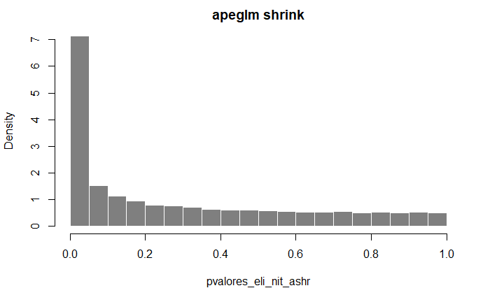

```r
# se quitan los genes cuyas cuentas normalizadas en promedio no llegan a 1 porque añaden ruido
pvalores_eli_nit_ashr <- eli_nit_ashr$pvalue[eli_nit_ashr$baseMean > 1]

hist(pvalores_eli_nit_ashr, breaks = 0:20/20,
     col = "grey50", border = "white", probability = T,
     main = "apeglm shrink")
```

# Anotación y análisis de expresión

```r
# corta los nombres a strings de 15, para dejar el nombre de ensembl y que así se pueda localizar con
# mapIds con las keys
ens.str <- substr(rownames(eli_nit), 1, 15)

columns(org.Hs.eg.db)
```

```
 [1] "ACCNUM"       "ALIAS"        "ENSEMBL"      "ENSEMBLPROT"  "ENSEMBLTRANS" "ENTREZID"
 [7] "ENZYME"       "EVIDENCE"     "EVIDENCEALL"  "GENENAME"     "GO"           "GOALL"
[13] "IPI"          "MAP"          "OMIM"         "ONTOLOGY"     "ONTOLOGYALL"  "PATH"
[19] "PFAM"         "PMID"         "PROSITE"      "REFSEQ"       "SYMBOL"       "UCSCKG"
[25] "UNIGENE"      "UNIPROT"
```

```r
eli_nit_ashr$SYMBOL <- mapIds(org.Hs.eg.db, keys=ens.str, keytype="ENSEMBL", multiVals="first",
                              column="SYMBOL") # la columna que añade
eli_nit_ashr$ENTREZID <- mapIds(org.Hs.eg.db, keys=ens.str, keytype="ENSEMBL", multiVals="first",
                                column="ENTREZID")
eli_nit_ashr$GO <- mapIds(org.Hs.eg.db, keys=ens.str, keytype="ENSEMBL", multiVals="first",
                          column="GO")
eli_nit_ashr$PATH <- mapIds(org.Hs.eg.db, keys=ens.str, keytype="ENSEMBL", multiVals="first",
                            column="PATH")
eli_nit_ashr$UNIPROT <- mapIds(org.Hs.eg.db, keys=ens.str, keytype="ENSEMBL", multiVals="first",
                               column="UNIPROT")
eli_nit_ashr$ENZYME <- mapIds(org.Hs.eg.db, keys=ens.str, keytype="ENSEMBL", multiVals="first",
                              column="ENZYME")
```

Ordeno por p-valor y le doy formato de dataframe

```r
eli_nit_DGE <- as.data.frame(eli_nit_ashr[order(eli_nit_ashr$pvalue),])
# tabla con todos los genes
write.csv(as.data.frame(eli_nit_DGE), file = "resultados/ElI vs NIT/DGE.csv")
```

Hago una tabla aparte con los 2006 genes de expresión diferencial.

```r
eli_nitSig <- as.data.frame(subset(eli_nit_ashr, padj < alpha & abs(log2FoldChange)>FC)) %>% arrange(-log2FoldChange)
# genes más sobreexpresados
head(eli_nitSig)
```

|  | baseMean | log2FoldChange | lfcSE | pvalue | padj | SYMBOL | ENTREZID | GO | PATH | UNIPROT | ENZYME |
| --- | --- | --- | --- | --- | --- | --- | --- | --- | --- | --- | --- |
| ENSG00000222037.5 | 997.93988 | 8.994947 | 0.9423225 | 2.095376e-23 | 1.836149e-20 | NA | NA | NA | NA | NA | NA |
| ENSG00000100721.6 | 368.81516 | 8.741617 | 1.0762117 | 7.227365e-18 | 1.318736e-15 | TCL1A | 8115 | GO:0005515 | NA | A0A024R6G5 | NA |
| ENSG00000253274.1 | 93.70213 | 8.315230 | 1.1140112 | 1.607521e-15 | 1.888005e-13 | NA | NA | NA | NA | NA | NA |
| ENSG00000254709.2 | 108.43128 | 8.213963 | 0.8868524 | 5.106504e-22 | 2.947332e-19 | IGLL5 | 100423062 | GO:0070062 | NA | B9A064 | NA |
| ENSG00000211619.2 | 116.38572 | 8.072525 | 1.2109877 | 4.987220e-13 | 3.555308e-11 | NA | NA | NA | NA | NA | NA |
| ENSG00000211593.2 | 3005.13820 | 8.054668 | 0.7906840 | 6.724365e-26 | 1.717739e-22 | NA | NA | NA | NA | NA | NA |

```r
# genes más subexpresados
tail(eli_nitSig)
```

|  | baseMean | log2FoldChange | lfcSE | pvalue | padj | SYMBOL | ENTREZID | GO | PATH | UNIPROT | ENZYME |
| --- | --- | --- | --- | --- | --- | --- | --- | --- | --- | --- | --- |
| ENSG00000006128.7 | 292.8586 | -2.752975 | 0.6714732 | 1.807686e-06 | 3.326099e-05 | TAC1 | 6863 | GO:0002675 | NA | P20366 | NA |
| ENSG00000158859.9 | 8564.1042 | -2.769532 | 0.6373949 | 7.465370e-07 | 1.516524e-05 | ADAMTS4 | 9507 | GO:0001501 | NA | O75173 | NA |
| ENSG00000140961.8 | 1699.5747 | -2.988750 | 0.6015875 | 4.693675e-08 | 1.285790e-06 | OSGIN1 | 29948 | GO:0005515 | NA | Q9UJX0 | NA |
| ENSG00000089225.15 | 274.5491 | -3.024354 | 0.9486706 | 2.378766e-05 | 3.057387e-04 | TBX5 | 6910 | GO:0000978 | NA | Q99593 | NA |
| ENSG00000079689.9 | 93.7118 | -4.731215 | 0.9577975 | 2.509362e-08 | 7.305031e-07 | SCGN | 10590 | GO:0005509 | NA | O76038 | NA |
| ENSG00000149968.7 | 290.7489 | -4.754970 | 1.3753124 | 6.595031e-06 | 1.030923e-04 | MMP3 | 4314 | GO:0004175 | 05323 | P08254 | NA |

```r
write.csv(as.data.frame(eli_nitSig), file = "resultados/ElI vs NIT/DGE_sig.csv")
```

# Análisis de sobrerrepresentación (ORA)

Consiste en un resumen de los procesos en los que más genes de los sobreexpresados y subexpresados intervienen. A continuación se muestran tanto las rutas metabólicas de KEGG como por categorías de GO más representadas. Fuente: https://yulab-smu.github.io/clusterProfiler-book/index.html

```r
# separo los genes
upregulated <- filter(eli_nitSig, log2FoldChange>FC)
downregulated <- filter(eli_nitSig, log2FoldChange<(-FC))
# Quito los NAs de EntrezID
upregulated <- upregulated[!is.na(upregulated$ENTREZID),]
downregulated <- downregulated[!is.na(downregulated$ENTREZID),]

nrow(upregulated)
```

```
[1] 1091
```

```r
nrow(downregulated)
```

```
[1] 58
```

Al eliminar los genes cuyos ENTREZID no se ha localizado se reduce el número de genes disponible, por eso upregulted + downregulated no suma lo mismo que los genes diferencialmente expresados. Si se hace la suma con los vectores sin na.omit coincide.

## GO

```r
upregulated_GO <- enrichGO(upregulated$ENTREZID,
                             OrgDb="org.Hs.eg.db",
                             pvalueCutoff=0.05,
                             qvalueCutoff=0.05,
                             ont = "BP")

upregulated_GO <- setReadable(upregulated_GO, "org.Hs.eg.db", keyType = "ENTREZID")

head(upregulated_GO)
```

|  | ID | Description | GeneRatio | BgRatio | pvalue | p.adjust | qvalue | geneID | Count |
| --- | --- | --- | --- | --- | --- | --- | --- | --- | --- |
| GO:0042110 | GO:0042110 | T cell activation | 123/802 | 443/17913 | 6.841488e-64 | 3.044462e-60 | 2.444212e-60 | TNFRSF13C/PLA2G2D/BTLA/SIRPG/TIGIT/CTLA4/LY9/LAX1/TNFSF11/IR…… | 123 |
| GO:0002694 | GO:0002694 | regulation of leukocyte activation | 118/802 | 492/17913 | 1.023746e-53 | 2.277835e-50 | 1.828734e-50 | CD19/TNFRSF13C/MZB1/STAP1/FCRL3/BTLA/SIRPG/TIGIT/CTLA4/LAX1/…… | 118 |
| GO:0051249 | GO:0051249 | regulation of lymphocyte activation | 104/802 | 401/17913 | 9.808655e-51 | 1.454950e-47 | 1.168090e-47 | CD19/TNFRSF13C/MZB1/FCRL3/BTLA/SIRPG/TIGIT/CTLA4/LAX1/TNFSF1…… | 104 |
| GO:0030098 | GO:0030098 | lymphocyte differentiation | 94/802 | 325/17913 | 2.343893e-50 | 2.607581e-47 | 2.093467e-47 | CR2/CD19/MS4A1/CD79A/FCRL3/PLA2G2D/AICDA/CTLA4/LY9/IRF4/RHOH…… | 94 |
| GO:0002521 | GO:0002521 | leukocyte differentiation | 106/802 | 485/17913 | 4.577654e-44 | 4.074112e-41 | 3.270854e-41 | CR2/CD19/MS4A1/CD79A/FCRL3/PLA2G2D/AICDA/UBD/CTLA4/LY9/TNFSF…… | 106 |
| GO:0050863 | GO:0050863 | regulation of T cell activation | 85/802 | 307/17913 | 7.100843e-44 | 5.266459e-41 | 4.228116e-41 | TNFRSF13C/BTLA/SIRPG/TIGIT/CTLA4/LAX1/TNFSF11/IRF4/CD28/SIT1…… | 85 |

```r
downregulated_GO <- enrichGO(downregulated$ENTREZID,
                             OrgDb="org.Hs.eg.db",
                             pvalueCutoff=0.05,
                             qvalueCutoff=0.05,
                             ont = "BP")

downregulated_GO <- setReadable(downregulated_GO, "org.Hs.eg.db", keyType = "ENTREZID")

head(downregulated_GO)
```

|  | ID | Description | GeneRatio | BgRatio | pvalue | p.adjust | qvalue | geneID | Count |
| --- | --- | --- | --- | --- | --- | --- | --- | --- | --- |
| GO:0010002 | GO:0010002 | cardioblast differentiation | 3/45 | 20/17913 | 1.639145e-05 | 0.01094064 | 0.008436933 | NRG1/TBXT/TBX5 | 3 |
| GO:0019748 | GO:0019748 | secondary metabolic process | 4/45 | 63/17913 | 1.857494e-05 | 0.01094064 | 0.008436933 | AKR1C2/SLC7A11/AKR1B10/CITED1 | 4 |
| GO:0045823 | GO:0045823 | positive regulation of heart contraction | 3/45 | 39/17913 | 1.270906e-04 | 0.03284148 | 0.025325881 | ACE2/ADRB1/CHGA | 3 |
| GO:1990748 | GO:1990748 | cellular detoxification | 4/45 | 107/17913 | 1.484862e-04 | 0.03284148 | 0.025325881 | TPO/SRXN1/AKR1B10/NQO1 | 4 |
| GO:0098754 | GO:0098754 | detoxification | 4/45 | 113/17913 | 1.832422e-04 | 0.03284148 | 0.025325881 | TPO/SRXN1/AKR1B10/NQO1 | 4 |
| GO:0042445 | GO:0042445 | hormone metabolic process | 5/45 | 215/17913 | 1.965402e-04 | 0.03284148 | 0.025325881 | ACE2/PCSK2/AKR1C2/TPO/AKR1B10 | 5 |

### Términos GO más representados:

```r
png("resultados/ElI vs NIT/imagenes/GO barplot.png", height = 1500, width = 2000, res=200)
  p1 # los subexpresados no tienen nada especialmente interesante
dev.off()
```

```r
# p1 <- dotplot(upregulated_GO, showCategory=20) + ggtitle("Categorias GO sobreexpresadas")
# p2 <- dotplot(downregulated_GO, showCategory=20) + ggtitle("Categorias GO subexpresadas")
#
# cairo_pdf("resultados/ELIvsNIT GO dotplot.pdf", height = 10, width = 20)
#   plot_grid(p1, p2, ncol=2)
# dev.off()
```

### Redes de términos GO:

```r
cairo_pdf("resultados/ElI vs NIT/upregulated GO network.pdf", height = 10, width = 20)
  cnetplot(upregulated_GO, foldChange=upregulated$log2FoldChange)
dev.off()
```

```r
png("resultados/ElI vs NIT/imagenes/upregulated GO network.png", height = 1500, width = 3000, res=200)
```

```r
  cnetplot(upregulated_GO, foldChange=upregulated$log2FoldChange)
dev.off()
```

```r
cairo_pdf("resultados/ElI vs NIT/downregulated GO network.pdf", height = 10, width = 20)
```

```r
  cnetplot(downregulated_GO, foldChange=upregulated$log2FoldChange)
dev.off()
```

```r
png("resultados/ElI vs NIT/imagenes/downregulated GO network.png", height = 1500, width = 3000, res=200)
```

```r
  cnetplot(downregulated_GO, foldChange=upregulated$log2FoldChange)
dev.off()
```

## KEGG

```r
upregulated_KEGG <- enrichKEGG(gene = upregulated$ENTREZID,
                               organism = 'hsa',
                               pvalueCutoff = 0.05)

upregulated_KEGG <- setReadable(upregulated_KEGG, "org.Hs.eg.db", keyType = "ENTREZID")

head(upregulated_KEGG)
```

|  | ID | Description | GeneRatio | BgRatio | pvalue | p.adjust | qvalue | geneID | Count |
| --- | --- | --- | --- | --- | --- | --- | --- | --- | --- |
| hsa04640 | hsa04640 | Hematopoietic cell lineage | 39/421 | 99/8040 | 6.137739e-25 | 1.565123e-22 | 1.240469e-22 | CR2/CD19/MS4A1/FCER2/CD37/HLA-DOB/CD22/CD5/CD1E/CD3E/CD3G/CD3D/CD2/CD1C/CR1L/CD8B/CD8B2/ITGA4/IL7R/HLA-DOA/HLA-DQA1/CR1/CD1B/TNF/HLA-DQB1/CD1A/CD8A/HLA-DPB1/CD7/FLT3/HLA-DRA/GP1BA/HLA-DPA1/HLA-DRB1/IT… | 39 |
| hsa05340 | hsa05340 | Primary immunodeficiency | 24/421 | 38/8040 | 4.683126e-22 | 5.970986e-20 | 4.732422e-20 | CD19/CD79A/TNFRSF13C/TNFRSF13B/AICDA/BTK/IL2RG/ICOS/LCK/CD3E/CD3D/ZAP70/PTPRC/IGLL1/CIITA/CD8B/CD40LG/CD8B2/IL7R/AIRE/CD8A/JAK3/TAP1/CD4 | 24 |
| hsa04060 | hsa04060 | Cytokine-cytokine receptor interaction | 58/421 | 294/8040 | 2.687824e-19 | 2.284650e-17 | 1.810745e-17 | TNFRSF13C/CXCL13/TNFRSF13B/LTB/TNFRSF17/CXCL10/CXCR5/TNFSF11…… | 58 |
| hsa04672 | hsa04672 | Intestinal immune network for IgA production | 22/421 | 49/8040 | 5.163319e-16 | 3.291616e-14 | 2.608835e-14 | TNFRSF13C/TNFRSF13B/AICDA/TNFRSF17/HLA-DOB/CD28/ICOS/CXCR4/CD40LG/ITGA4/CCL25/HLA-DOA/HLA-DQA1/HLA-DQB1/HLA-DPB1/ITGB7/CD86/HLA-DRA/HLA-DPA1/HLA-DRB1/TNFSF13B/IL2 | 22 |
| hsa04514 | hsa04514 | Cell adhesion molecules (CAMs) | 35/421 | 148/8040 | 1.756260e-14 | 8.956924e-13 | 7.098987e-13 | TIGIT/CTLA4/HLA-DOB/CD28/SELL/CD6/CD22/ICOS/ITGAL/CD2/PDCD1/PTPRC/SPN/CD8B/CD40LG/CD8B2/ITGA4/HLA-DOA/HLA-DQA1/HLA-DQB1/CD8A/SELPLG/ICAM3/HLA-DPB1/ITGB7/CD86/HLA-F/ITGB2/HLA-DRA/HLA-DPA1/HLA-DRB1/NTNG… | 35 |
| hsa04660 | hsa04660 | T cell receptor signaling pathway | 28/421 | 104/8040 | 2.528338e-13 | 1.074544e-11 | 8.516507e-12 | CTLA4/CD28/CARD11/ICOS/LCK/CD3E/CD3G/CD3D/ITK/ZAP70/PDCD1/CD247/PTPRC/RASGRP1/GRAP2/VAV1/CD8B/CD40LG/CD8B2/TNF/CD8A/IFNG/LCP2/PIK3CD/PTPN6/CD4/IL2/LAT | 28 |

```r
downregulated_KEGG <- enrichKEGG(gene = downregulated$ENTREZID,
                               organism = 'hsa',
                               pvalueCutoff = 0.05)

downregulated_KEGG <- setReadable(downregulated_KEGG, "org.Hs.eg.db", keyType = "ENTREZID")

head(downregulated_KEGG)
```

| ID | Description | GeneRatio | BgRatio | pvalue | p.adjust | qvalue | geneID | Count |
| --- | --- | --- | --- | --- | --- | --- | --- | --- |

No encuentra ninguna ruta sobrerrepresentada en los NIT, me centro en las muestras ELI.

### Rutas KEGG más representadas:

```r
p1 <- barplot(upregulated_KEGG, showCategory = 20) + ggtitle("Rutas KEGG sobreexpresadas")

cairo_pdf("resultados/ElI vs NIT/KEGG barplot.pdf", height = 10, width = 10)
  p1
dev.off()
```

```r
png("resultados/ElI vs NIT/imagenes/KEGG barplot.png", height = 1500, width = 2000, res=200)
```

```r
  p1
dev.off()
```

### Redes de rutas KEGG:

```r
cairo_pdf("resultados/ElI vs NIT/upregulated KEGG network.pdf", height = 10, width = 20)
    cnetplot(upregulated_KEGG, foldChange=upregulated$log2FoldChange)
dev.off()
```

```r
png("resultados/ElI vs NIT/imagenes/upregulated KEGG network.png", height = 1500, width = 2000, res=200)
```

```r
  cnetplot(upregulated_KEGG, foldChange=upregulated$log2FoldChange)
dev.off()
```

```r
library(beepr)
beep(3)
```

Conesa, Ana, Pedro Madrigal, Sonia Tarazona, David Gomez-Cabrero, Alejandra Cervera, Andrew McPherson, Michal Wojciech Szcześniak, et al. 2016. “A survey of best practices for RNA-seq data analysis.” *Genome Biology* 17 (1): 1–19. https://doi.org/10.1186/s13059-016-0881-8.